# Delta Smelt conditions report (2002 - present)

*Delta Science Program*

*Oct 02, 2020*

# Accessibility

For any assistance accessing the map, graphs, images, or other material in this report, please contact us at accessibility@deltacouncil.ca.gov.

# Erratum

A prior version of this report contained an incorrect zooplankton graph and dataset. This version of the report has now been corrected but [the original report with the incorrect zooplankton data is here for reference](https://sbashevkin.github.io/deltareportr/Delta_Smelt_conditions_report_2018.html).

# Introduction

This report is intended for managers and scientists interested in tracking environmental conditions considered important for Delta Smelt (*Hypomesus transpacificus*). The variables shown in this report represent a selected subset of the variables that have been incorporated into conceptual models of Delta Smelt life history and analyses of the Delta Smelt population and its habitat. The variables selected have also been consistently measured as part of the long term monitoring efforts of the Interagency Ecological Program and other entities. Data for selected variables are summarized from 2002 to present, to reflect conditions since the beginning of the Pelagic Organism Decline. The report does not include data from short-term special studies. This report also does not provide detailed assessments of trends or the outcomes of specific management actions. Such assessments require specialized analysis and synthesis by expert teams and are beyond the scope of this report.

Delta Smelt is a pelagic species that prefers cooler temperatures (< 22 °C) in low salinity (0 - 6), turbid habitats. Some additional habitat concerns are food availability, invasive species, contaminants and harmful algal blooms.

Delta Smelt is generally described as a semi-anadromous species, moving from brackish low salinity (0.5-6 PSU) habitats to tidal fresh water habitats to spawn; however, the species expresses a variety of life histories. These spawning movements generally occur in the winter, after the “first-flush” of turbid freshwater following the first major precipitation event. A variable proportion of the population also exhibit resident life histories, residing in freshwater or brackish water for their entire life cycle.

Since the POD (Pelagic Organism Decline, 2002-2003), Delta Smelt have been most commonly found in the North Delta region (Cache Slough/Liberty Island and Sacramento River Deep Water Shipping Channel) during the winter spawning season. Larval and juvenile fish of the migratory life history move into low salinity habitat (Suisun Bay and Marsh, Lower Sacramento River) during the spring and early summer and remain there until their winter spawning movements into fresh water. The Lower San Joaquin River and Southern Delta are highly modified habitats characterized by warm summer temperatures and low turbidities with low abundance of Delta Smelt. Proximity to the water export facilities, which may result in some probability of entrainment under some environmental conditions and operations, may also be a factor.

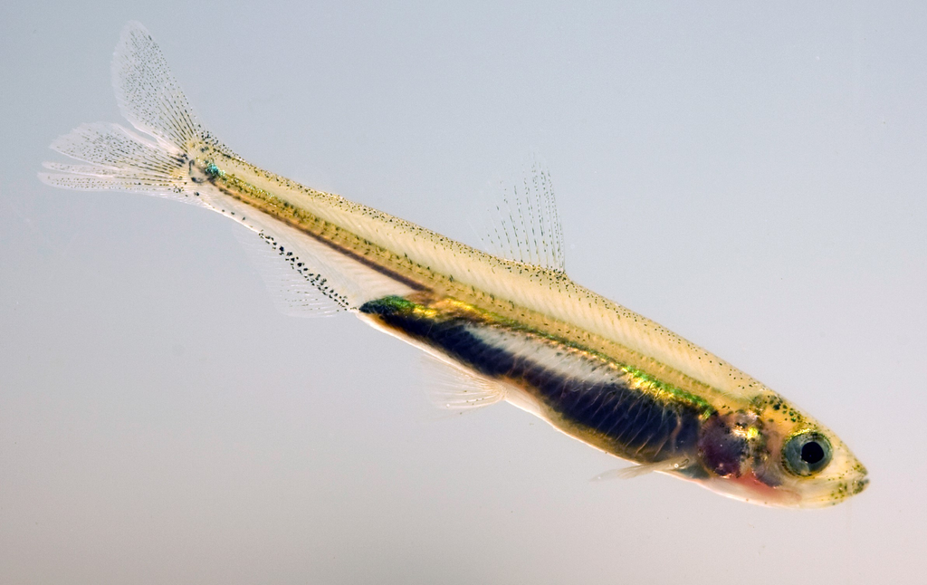

Figure 1: Juvenile Delta Smelt Dale Kolke / DWR.

# Methods

Most variables are divided among 7 of the 8 regions from the [Enhanced Delta Smelt Monitoring (EDSM)](https://www.fws.gov/lodi/juvenile_fish_monitoring_program/jfmp_index.htm) 2018-19 phase I strata, with the Western Delta region excluded because it is almost never occupied by Delta Smelt. Missing data are denoted by vertical dashed lines. Data are plotted from 2002 (or the start of data collection) until present. The graphs presented in this report are for the season when a selected variable is most critical in the life history of Delta Smelt, as determined from literature. The graphs also highlight in red the most recent year, to facilitate visual comparisons of recent conditions with previous years. This report will be produced annually.

[figure not shown]

Figure 2: The Sacramento San Joaquin Delta divided into the EDSM 2018-19 phase I strata (Suisun Bay, Suisun Marsh, Lower Sacramento River, Sacramento Deep Water Shipping Channel, Cache Slough/Liberty Island, Lower San Joaquin River, and the Southern Delta).

## Sampling programs

Table 1: Acronyms and responsible agencies for each dataset used in this report.

| Acronym | Dataset name | Agency |
| --- | --- | --- |
| EMP | Environmental Monitoring Program | California Department of Fish and Wildlife; Department of Water Resources |
| FMWT | Fall Midwater Trawl | California Department of Fish and Wildlife |
| SKT | Spring Kodiak Trawl | California Department of Fish and Wildlife |
| STN | Summer Townet | California Department of Fish and Wildlife |
| 20mm | 20 mm Survey | California Department of Fish and Wildlife |
| EDSM | Enhanced Delta Smelt Monitoring | United States Fish and Wildlife Service |
| Dayflow | Dayflow | Department of Water Resources |

## Definitions of seasons

Table 2: Definitions of seasons as used in this report.

| Season | Months |
| --- | --- |
| Winter | December (of prior year), January, February |
| Spring | March, April, May |
| Summer | June, July, August |
| Fall | September, October, November |

## Sampling effort

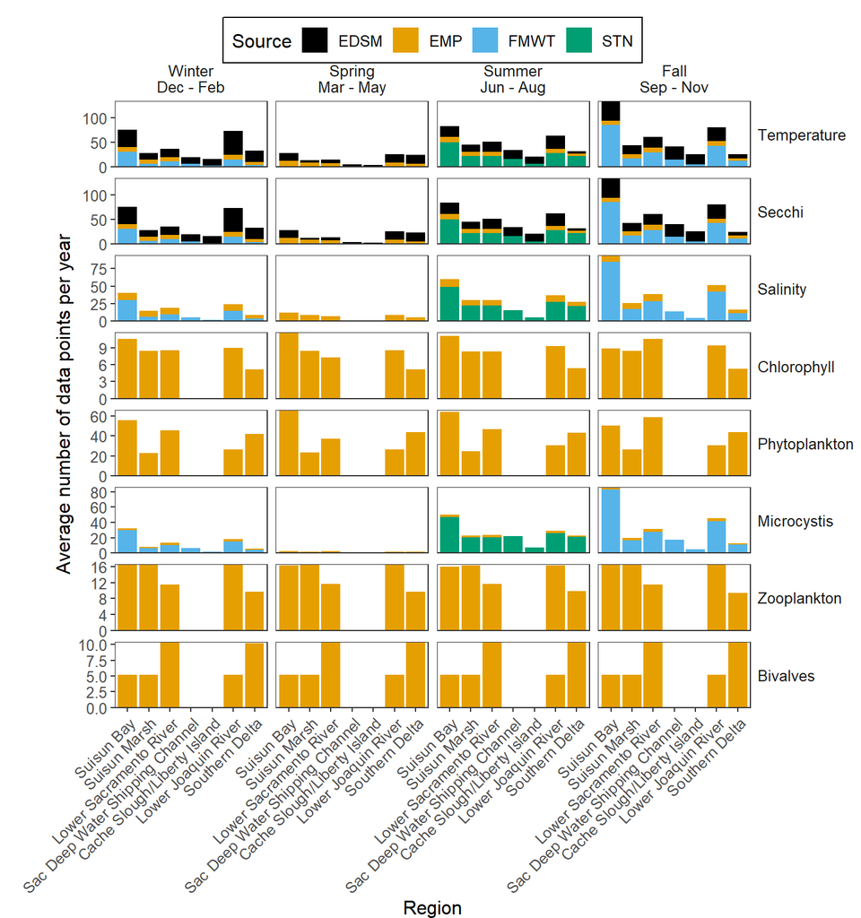

Figure 3: Average yearly sampling effort for each variable, region, season, and survey. Cyanobacteria data are included in the phytoplankton category. Delta Outflow and X2 are derived from the Dayflow model while Delta Smelt abundance is represented by the official indices produced by FMWT, SKT, STN, 20mm, and EDSM. Raw data are available in table 3.

# Abiotic drivers

## Delta outflow

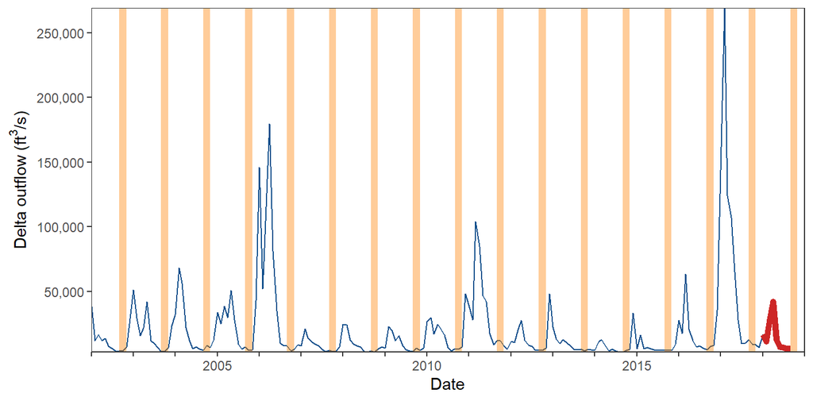

Figure 4: Monthly modeled Delta outflow from the Dayflow model. Fall months are highlighted in orange. Raw data are available in table 4.

Delta Smelt abiotic habitat (as defined by salinity, turbidity, and water temperature) is determined largely by freshwater flow because Delta Smelt occupy the fresh, and low salinity portion of the SFE during the summer and fall. **High Delta outflow in the summer-fall increases the amount of low salinity habitat available in Suisun Bay and Suisun Marsh. This is thought to be favorable for Delta Smelt.** High outflow may also improve other abiotic environmental conditions and reduce harmful algal blooms.

## X2

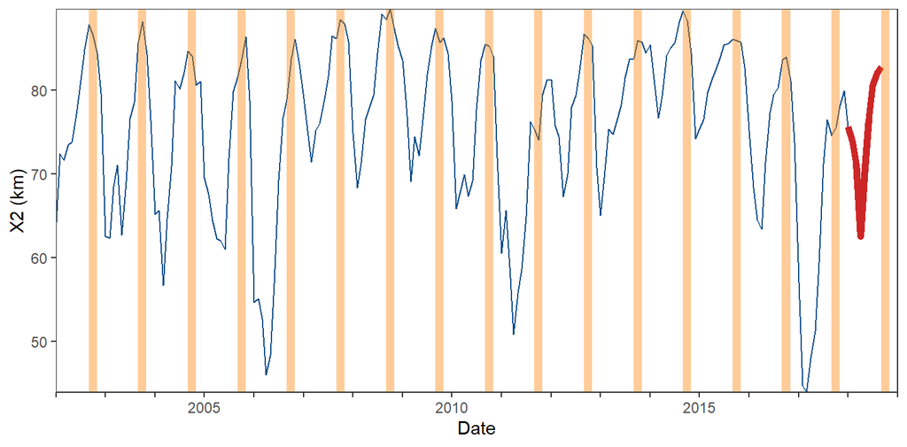

Figure 5: Monthly modeled X2 from the Dayflow model. Fall months are highlighted in orange. Raw data are available in table 4.

X2 is a measure of the location of low salinity habitat. X2 is defined as the horizontal distance in kilometers from the Golden Gate up the axis of the estuary to where tidally averaged near-bottom salinity is 2. X2 is used as a proxy for the amount of low salinity habitat in the Delta; **lower X2 in the fall generally means more low salinity habitat is available**.

## Summer temperature

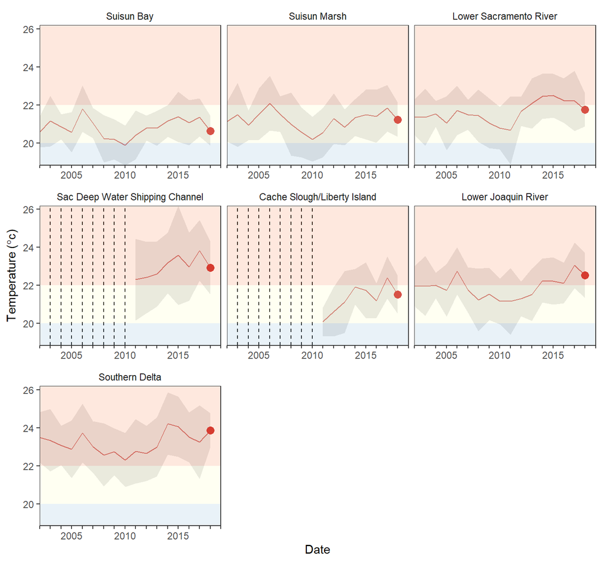

Figure 6: Mean summer water temperature from discrete measurements collected by the STN, EMP, and EDSM surveys, shaded by suitability for Delta Smelt (bottom blue section under 20 °C = good, middle yellow section between 20 and 22 °C = marginal, top red section over 22 °C = bad). Gray shading represents the standard deviation across all measurements from the summer of each year. Vertical dotted lines represent years with missing data. Raw data are available in table 5.

Delta Smelt are sensitive to high water temperatures. Results from laboratory and observational studies suggest that **Delta Smelt growth is optimal at water temperatures ≤ 20 °C**, growth likely declines at 20-22 °C with poor growth at 22-24 °C, and the onset of physiological stress around 24 °C. Chronic exposure to water temperatures above 26 °C are likely fatal. Delta Smelt are rarely captured above 22 °C.

## Fall Secchi depth

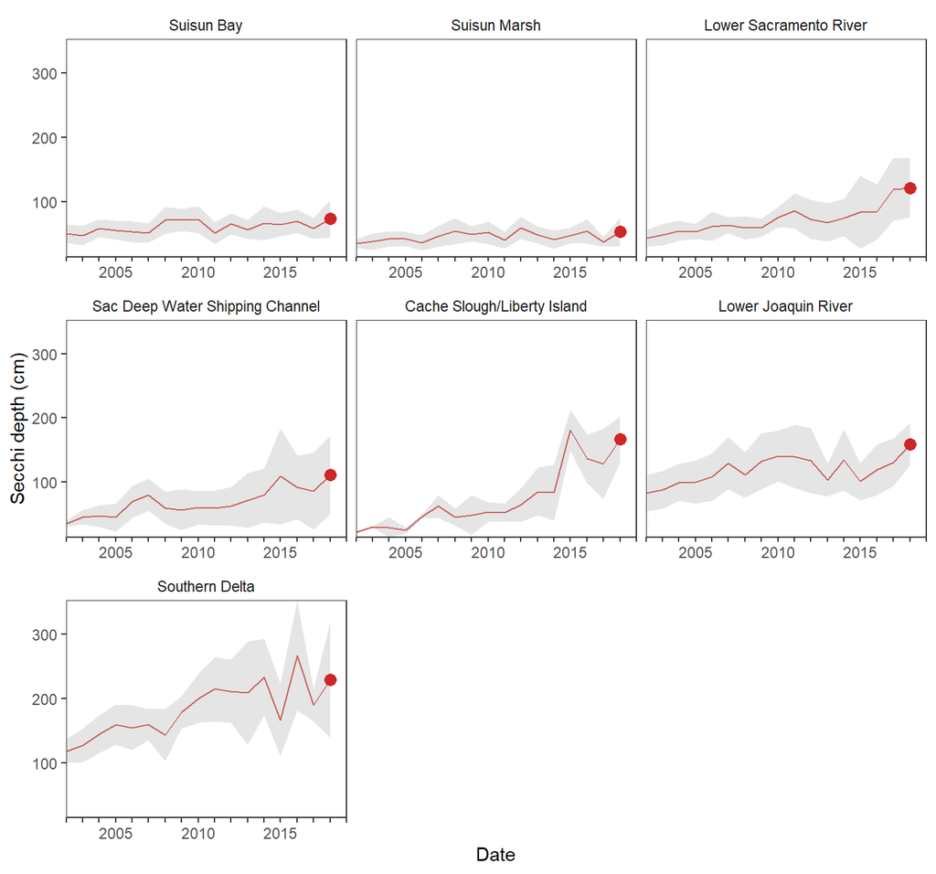

Figure 7: Mean fall Secchi depth from the FMWT, EMP, and EDSM surveys. Means were calculated by pooling discrete measurements of the three surveys for the fall of each year. Gray shading represents the standard deviation across all measurements from the fall of each year. Raw data are available in table 6.

Secchi depth is a measure of turbidity. **Lower Secchi depth indicates higher turbidity, which is preferred by Delta Smelt**. Delta Smelt distributions are clustered around areas with low Secchi depth (high turbidity) in the fall. Delta Smelt evolved in the historically turbid San Francisco Estuary and the larvae rely on this turbidity to effectively feed and hide from predators.

## Fall salinity

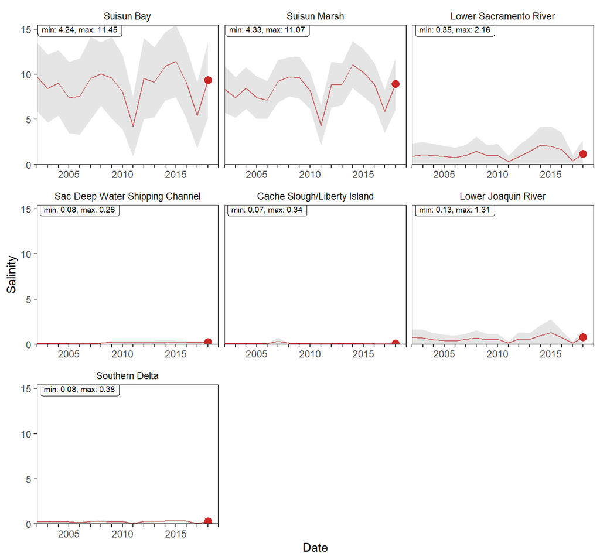

Figure 8: Mean fall salinity from the FMWT and EMP surveys. Means were calculated by pooling discrete measurements of the two surveys for the fall of each year. Gray shading represents the standard deviation across all measurements from the fall of each year. Raw data are available in table 7.

**During the fall, Delta Smelt prefer fresh to brackish water are most abundant in salinities less than about 6 PSU**, decline in abundance at higher salinities, and become rare at salinities above about 14 PSU. Juveniles rely on freshwater and low salinity habitat in the fall to feed, grow, and mature into adults.

# Biotic drivers

## Summer chlorophyll concentrations

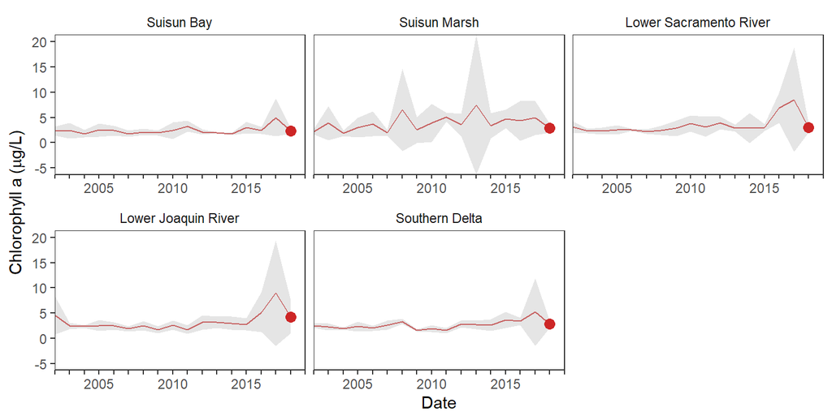

Figure 9: Mean summer chlorophyll concentrations from EMP. Means were calculated by pooling discrete measurements for the summer of each year. No data are available from the Sac Deep Water Shipping Channel or Cache/Slough/Liberty Island regions. Gray shading represents the standard deviation across all measurements from the summer of each year. Raw data are available in table 8.

Chlorophyll is a measure of productivity at the base of the food web. **Higher chlorophyll is an indicator of more food availability for zooplankton, which are important prey for many fish, including Delta Smelt.**

## Summer phytoplankton composition

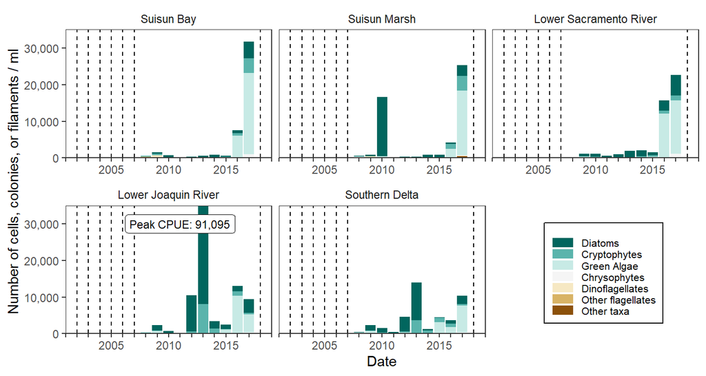

Figure 10: Summer phytoplankton community composition from EMP. Cyanobacteria are presented in figure 11. Means were calculated by pooling discrete measurements for the summer of each year. No data are available from the Sac Deep Water Shipping Channel or Cache/Slough/Liberty Island regions. Data are only shown from 2008 - 2018 to reflect the time frame of consistent sample processing methodology. Vertical dotted lines represent years with missing data. Raw data are available in table 9.

Phytoplankton are the base of the aquatic food web. They provide food for zooplankton, which are important prey for Delta Smelt. **Diatoms and cryptophytes are currently considered the best quality zooplankton food, although other taxa may be important as well.**

## Summer cyanobacteria

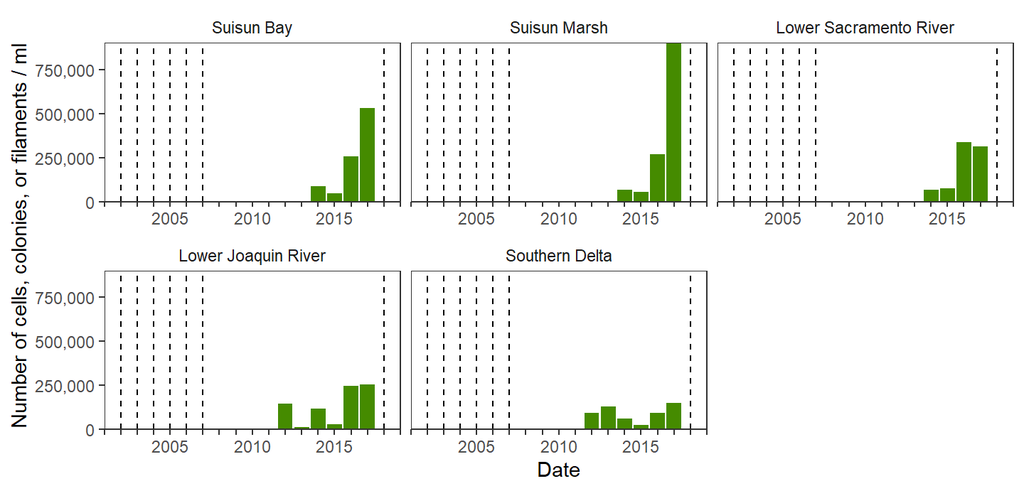

Figure 11: Summer cyanobacteria abundance from EMP. Means were calculated by pooling discrete measurements for the summer of each year. No data are available from the Sac Deep Water Shipping Channel or Cache/Slough/Liberty Island regions. Data are only shown from 2008 - 2018 to reflect the time frame of consistent sample processing methodology. Vertical dotted lines represent years with missing data. Raw data are available in table 9.

**Cyanobacteria are an unfavorable type of phytoplankton** Cyanobacteria are considered poor quality zooplankton food and can produce toxins, such as microcystins.

## Summer *Microcystis*

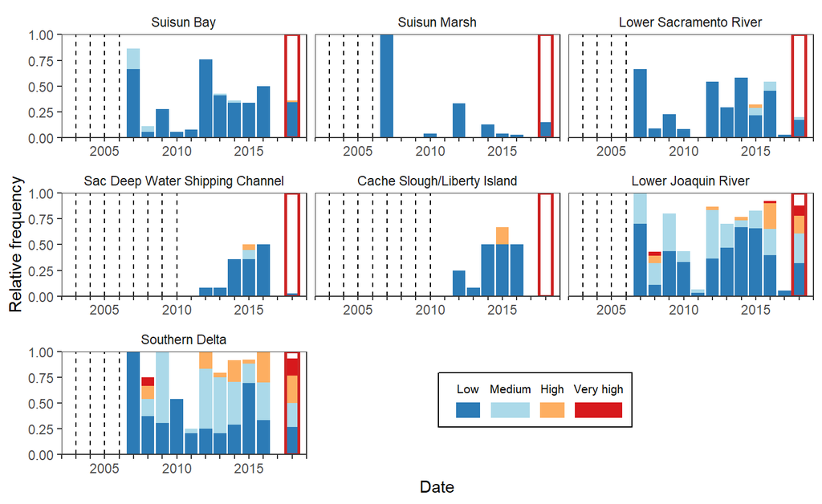

Figure 12: Summer *Microcystis* bloom intensity from EMP and STN. Means were calculated by pooling discrete measurements from the two surveys for the summer of each year. *Microcystis* bloom presence and intensity are measured on a qualitative scale with 5 categories: absent, low (widely scattered colonies), medium (adjacent colonies), high (contiguous colonies), and very high (concentration of contiguous colonies forming mats/scum). Vertical dotted lines represent years with missing data. Raw data are available in table 10.

*Microcystis* is a toxin-producing cyanobacteria. The toxins, microcystins, are harmful to human and animal health. *Microcystis* toxins can directly harm zooplankton populations which may affect food resources for Delta Smelt. Blooms occur yearly in the summer and fall.

## Fall zooplankton

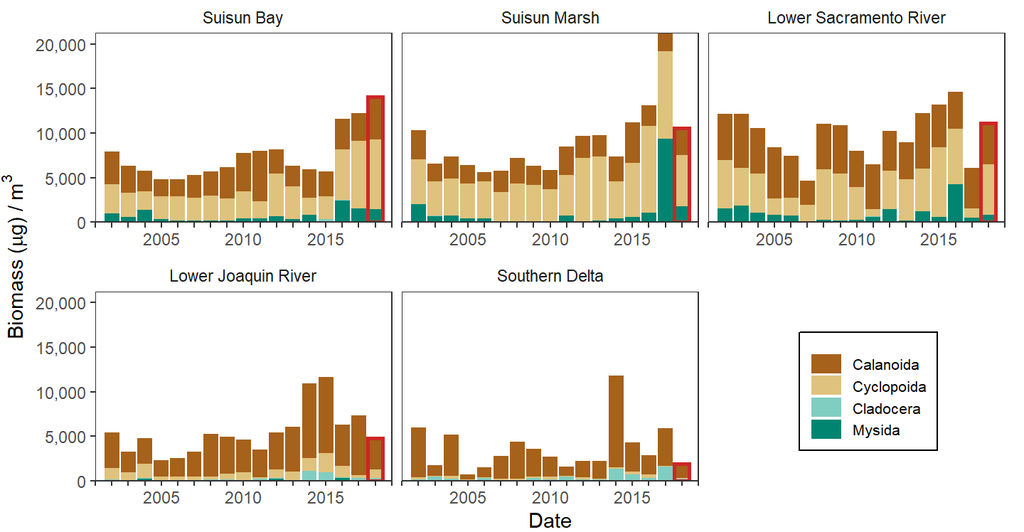

Figure 13: Fall zooplankton biomass and composition from EMP. Means were calculated by pooling discrete measurements for the fall of each year. No data are available from the Sac Deep Water Shipping Channel or Cache/Slough/Liberty Island regions. Raw data are available in table 11.

Delta Smelt rely on zooplankton for food throughout their entire lives. **Calanoid copepods and mysids are particularly important in the diet of Delta Smelt.**

## Fall invasive bivalve abundance

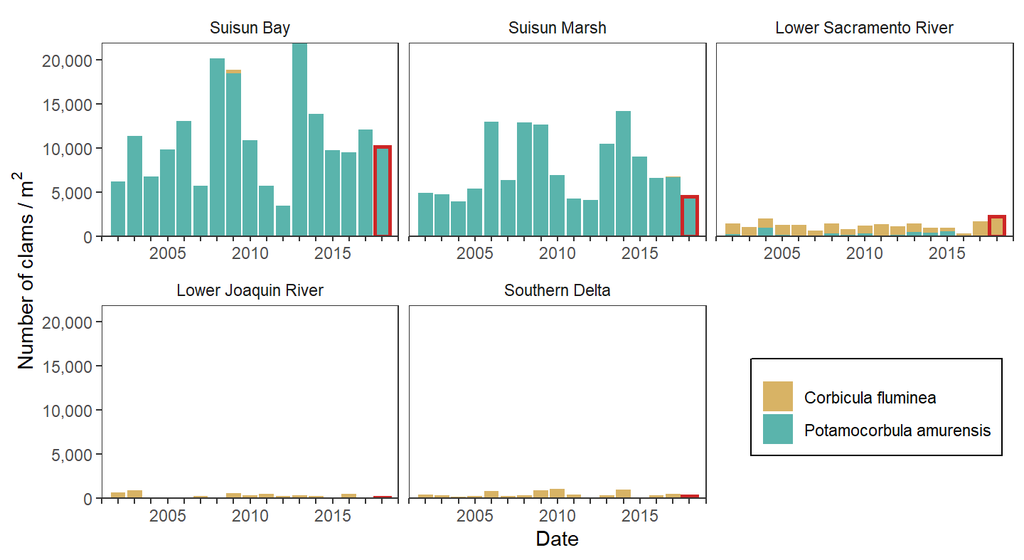

Figure 14: Fall abundance of two invasive bivalve species (the overbite clam *Potamocorbula amurensis* and the freshwater clam *Corbicula fluminea*) from EMP. Means were calculated by pooling discrete measurements for the fall of each year. No data are available from the Sac Deep Water Shipping Channel or Cache/Slough/Liberty Island regions. Raw data are available in table 12.

**Invasive bivalves (clams) consume phytoplankton and zooplankton, reducing the amount of food available for fishes.** The overbite clam *Potamocorbula amurensis* invaded the estuary in 1987, prefers brackish waters, and feeds on both zooplankton and phytoplankton. The freshwater clam *Corbicula fluminea* invaded sometime before 1945, prefers freshwater, and feeds primarily on phytoplankton but can also feed on organic material in the substrate when phytoplankton are rare.

# Delta Smelt

## IEP Delta Smelt index values

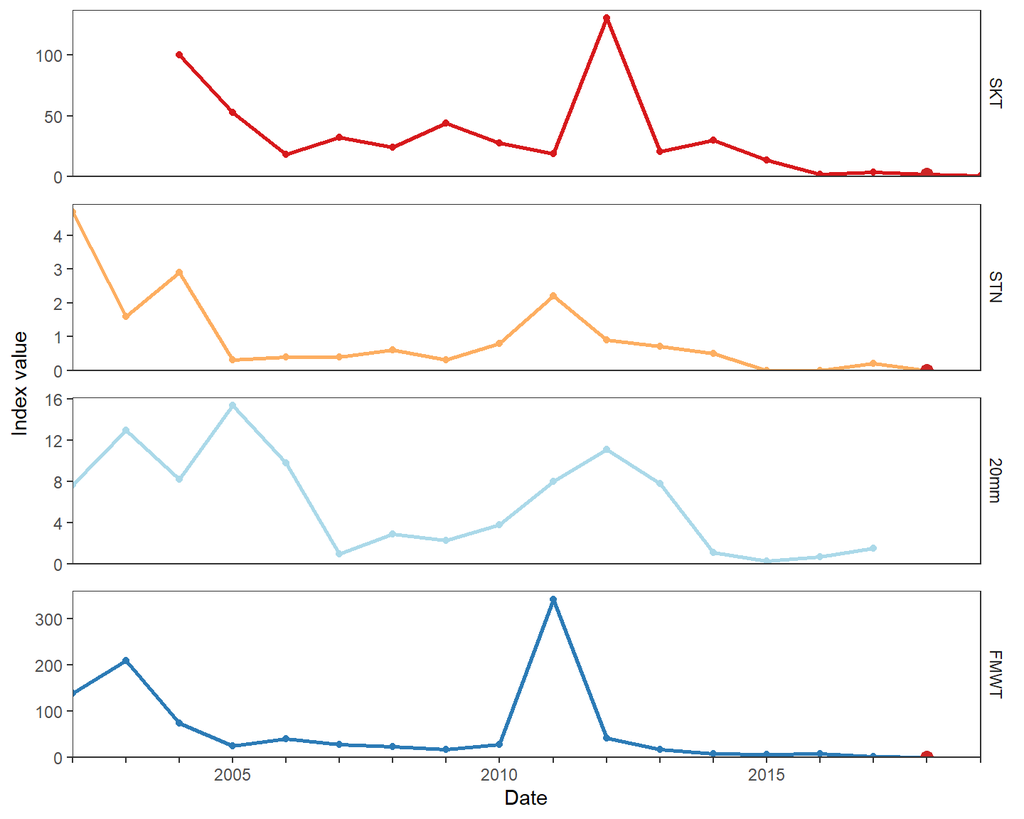

Figure 15: Official Delta Smelt indices from four Interagency Ecological Program (IEP) surveys: Spring Kodiak Trawl (SKT), the Summer Townet Survey (STN), the 20mm survey, and the Fall Midwater Trawl (FMWT). The 20mm index could not be calculated in 2018 due to low catch. For all surveys, indices are calculated from selected set of stations that have been consistently sampled over the full time series of the survey. Raw data are available in table 13.

Delta Smelt abundance is estimated by 4 IEP surveys that target different life stages. The Spring Kodiak Trawl (SKT) estimates spawning adult Delta Smelt abundance from January through May, the Summer Townet Survey (STN) estimates juvenile Delta Smelt abundance in June, the 20mm survey estimates larval and juvenile Delta Smelt abundance from March through August, and the Fall Midwater Trawl (FMWT) estimates juvenile and adult Delta Smelt abundance from September through December.

## EDSM Delta Smelt abundance

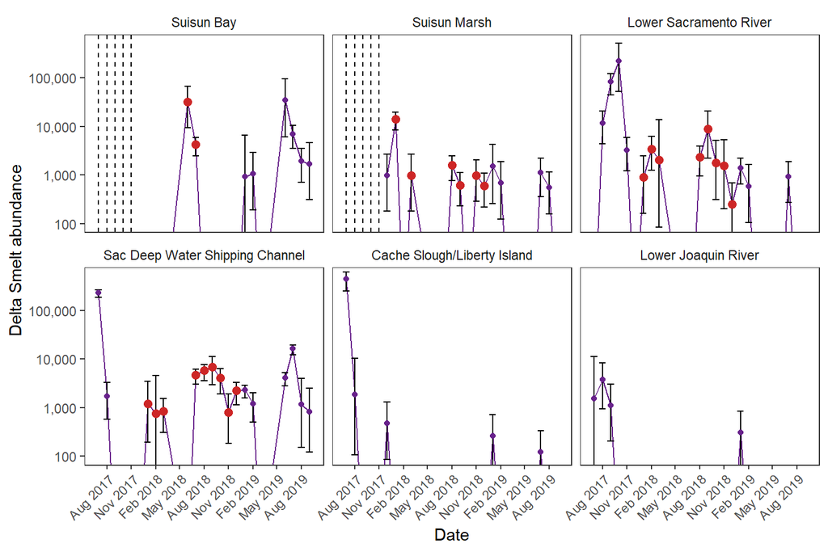

Figure 16: Monthly Delta Smelt abundance estimates (with 95% confidence intervals) from the Enhanced Delta Smelt Monitoring survey (EDSM). No Delta Smelt were collected from the Southern Delta. Vertical dotted lines represent months with missing data. Note that the y-axis is on the log scale and the x axis starts in mid 2017. The y axis starts at the lowest estimated detection value; all values below the limit are 0s. Raw data are available in table 14.

EDSM is a new survey that calculates Delta Smelt abundance estimates throughout the year.

# Recent publications

- [Castillo et al. 2019. Evaluation of chromatophores as natural marks for delta smelt: the effects of life-stage and light intensity. Environmental Biology of Fishes. 102:9 1137-1147](https://link.springer.com/article/10.1007/s10641-019-00893-4)
- [Castillo 2019. Modeling the influence of outflow and community structure on an endangered fish population in the upper San Francisco estuary. Water. 11:6 1162](https://www.mdpi.com/2073-4441/11/6/1162)
- [Davis et al. 2019. Sensitivities of an endemic, endangered California smelt and two non-native fishes to serial increases in temperature and salinity: implications for shifting community structure with climate change. Conservation Physiology. 7:1 coy076](https://academic.oup.com/conphys/article/7/1/coy076/5334620)
- [Davis et al. 2019. Consequences of temperature and temperature variability on swimming activity, group structure, and predation of endangered delta smelt. Freshwater Biology. 64:12 2156-2175](https://onlinelibrary.wiley.com/doi/abs/10.1111/fwb.13403)
- [Hammock et al. 2019. Tidal wetlands associated with foraging success of Delta Smelt. Estuaries and Coasts. 42:3 857-867](https://link.springer.com/article/10.1007/s12237-019-00521-5)
- [Hobbs et al. 2019. Complex life histories discovered in a critically endangered fish. Scientific Reports. 9 16772](https://www.nature.com/articles/s41598-019-52273-8)
- [Hung et al. 2019. A pilot study of the performance of captive-reared delta smelt *Hypomesus transpacificus* in a semi-natural environment. Journal of Fish Biology. 95:6 1517-1522](https://onlinelibrary.wiley.com/doi/full/10.1111/jfb.14162)
- [Jin et al. 2019 Sub-lethal effects of herbicides penoxsulam, imazamox, fluridone and glyphosate on Delta Smelt (*Hypomesus transpacificus*). Aquatic Toxicology. 197 79-88](https://www.sciencedirect.com/science/article/abs/pii/S0166445X18300663)
- [Kimerer et al. 2019. Effects of drought and the emergency drought barrier on the ecosystem of the California delta. San Francisco Estuary and Watershed Sciences. 17:3 2](https://escholarship.org/uc/item/0b3731ph)
- [Lindberg et al. 2020. Spawning microhabitat selection in wild-caught Delta Smelt *Hypomesus transpacificus* under laboratory conditions. Estuaries and Coasts. 43:1 174-181](https://link.springer.com/article/10.1007/s12237-019-00672-5)
- [Mahardja et al. 2019. Role of freshwater floodplain-tidal slough complex in the persistence of the endangered Delta Smelt. PLOS ONE. 14:1 e0208084](https://journals.plos.org/plosone/article?id=10.1371/journal.pone.0208084)
- [Mitchell et al. 2019. Estimating the size selectivity of fishing trawls for a short-lived fish species. San Francisco Estuary and Watershed Sciences. 17:1 5](https://escholarship.org/uc/item/0hh7n9x2)
- [Murphy and Weiland 2019. The low-salinity zone in the San Francisco Estuary as a proxy for delta smelt habitat: A case study in the misuse of surrogates in conservation planning. Ecological Indicators. 105 29-35](https://www.sciencedirect.com/science/article/pii/S1470160X1930398X)
- [Polansky et al. 2019. Using multistage design-based methods to construct abundance indices and uncertainty measures for Delta Smelt. Transactions of the American Fisheries Society. 148:4 710-724](https://afspubs.onlinelibrary.wiley.com/doi/abs/10.1002/tafs.10166)
- [Romney et al. 2019. Developmental staging and salinity tolerance in embryos of the delta smelt, *Hypomesus transpacificus*. Aquaculture. 511 634191](https://www.sciencedirect.com/science/article/abs/pii/S0044848619301425)
- [Sandford et al. In press. A review of fish identification methods applied on small fish. Reviews in Aquaculture](https://onlinelibrary.wiley.com/doi/abs/10.1111/raq.12339)
- [Schultz, A. A., editor. 2019. Directed Outflow Project: Technical Report 1. U.S. Bureau of Reclamation](https://www.usbr.gov/mp/bdo/directed-outflow.html)
- [Simonis and Merz 2019. Prey availability, environmental constraints, and aggregation dictate population distribution of an imperiled fish. Ecosphere. 10:3 e02634](https://esajournals.onlinelibrary.wiley.com/doi/full/10.1002/ecs2.2634)
- [Smith 2019. Integration of transport, survival, and sampling efficiency in a model of south delta entrainment. San Francisco Estuary and Watershed Sciences. 17:4 4](https://escholarship.org/uc/item/893826f3)
- [Tamburello et al. 2019. Durability of environment–recruitment relationships in aquatic ecosystems: insights from long-term monitoring in a highly modified estuary and implications for management. Limnology and Oceanography. 64:S1 S223-S239](https://aslopubs.onlinelibrary.wiley.com/doi/full/10.1002/lno.11037)
- [Weinersmith et al. 2019. Diets of Largemouth Bass (*Micropterus salmoides*) in the Sacramento–San Joaquin Delta. San Francisco Estuary and Watershed Sciences. 17:1 3](https://escholarship.org/uc/item/9mn0v9qb)
- [Willmes et al. 2019. Calibrating temperature reconstructions from fish otolith oxygen isotope analysis for California’s critically endangered Delta Smelt. Rapid Communications in Mass Spectrometry. 33:14 1207-1220](https://onlinelibrary.wiley.com/doi/abs/10.1002/rcm.8464)

# Data appendix

## Detailed methods

Data collected from 2002 - present within our regional strata were included in this report. We used regional strata from the Enhanced Delta Smelt Monitoring (EDSM) 2018-19 phase I strata. The Western Delta region was excluded because it is almost never occupied by Delta Smelt. Temperature, Secchi depth, salinity, chlorophyll, phytoplankton, cyanobacteria, zooplankton, and bivalve data were first filtered to only include data within the season of interest, then annual means within each region were calculated. Monthly means were calculated for outflow and X2. The relative frequencies of Microcystis index values (1-5) were calculated for each year and region. Official Delta Smelt indices were used from the Fall Midwater Trawl (FMWT), Spring Kodiak Trawl (SKT), Summer Townet (STN), and 20-mm (20mm) surveys. Official abundance estimates from EDSM were averaged monthly within each region and confidence intervals were calculated based on the lognormal distribution as described in Polansky et al. (2019).

## Data sources

Sources **bolded** below were used in the FLOAT MAST report. This section lists data sources available for all seasons. For data sources included in specific focal seasons, as well as sampling effort in each region, see figure 3.

### Outflow

1. **Dayflow**

### X2

1. **Dayflow**

### Water Temperature

1. EMP
2. FMWT
3. STN
4. EDSM

### Secchi depth

1. EMP
2. **FMWT**
3. STN
4. **EDSM**

### Salinity

1. EMP
2. FMWT
3. STN

### Chlorophyll-a

1. **EMP**

### Phytoplankton

1. **EMP**

### Cyanobacteria

1. **EMP**

### Microcystis

1. **EMP**

### Zooplankton

1. **EMP**

### Bivalve biomass

1. **EMP**

### Delta Smelt Abundance

1. **FMWT**
2. **SKT**
3. **STN**
4. **20mm**
5. EDSM

## Raw data

### Sampling effort

Table 3: Data from figure 3.

| Region | Season | Source | Parameter | Years sampled | Total samples | Samples per year |
| --- | --- | --- | --- | --- | --- | --- |
| Cache Slough/Liberty Island | Fall | EDSM | Secchi | 18 | 382 | 21.22 |
| Cache Slough/Liberty Island | Fall | EDSM | Temperature | 18 | 382 | 21.22 |
| Cache Slough/Liberty Island | Fall | FMWT | Microcystis | 13 | 65 | 5 |
| Cache Slough/Liberty Island | Fall | FMWT | Salinity | 18 | 79 | 4.39 |
| Cache Slough/Liberty Island | Fall | FMWT | Secchi | 18 | 79 | 4.39 |
| Cache Slough/Liberty Island | Fall | FMWT | Temperature | 18 | 79 | 4.39 |
| Cache Slough/Liberty Island | Spring | EDSM | Secchi | 18 | 53 | 2.94 |
| Cache Slough/Liberty Island | Spring | EDSM | Temperature | 18 | 53 | 2.94 |
| Cache Slough/Liberty Island | Summer | EDSM | Secchi | 18 | 281 | 15.61 |
| Cache Slough/Liberty Island | Summer | EDSM | Temperature | 18 | 279 | 15.5 |

[output cut: 290 more lines]

### Outflow and X2

Table 4: Data from figure 4 and figure 5. Outflow is in ft<sup>3</sup>/s and X2 is in km.

| Month | Year | Outflow | X2 |
| --- | --- | --- | --- |
| 1 | 2002 | 38731.42 | 64.19 |
| 2 | 2002 | 12029.68 | 72.36 |
| 3 | 2002 | 16982.13 | 71.66 |
| 4 | 2002 | 11943.23 | 73.45 |
| 5 | 2002 | 13554.23 | 73.82 |
| 6 | 2002 | 7461.77 | 77.13 |
| 7 | 2002 | 5731.84 | 81.22 |
| 8 | 2002 | 3848.58 | 84.88 |
| 9 | 2002 | 4168.93 | 87.84 |
| 10 | 2002 | 4203.26 | 86.58 |

[output cut: 191 more lines]

### Summer temperature

Table 5: Data from figure 6. Standard deviation and temperature are in °C. Temperatures under 20 °C are good, between 20 and 22 °C are marginal, and over 22 °C are bad for Delta Smelt.

| Year | Region | Standard deviation | Temperature |
| --- | --- | --- | --- |
| 2002 | Lower Joaquin River | 1.05 | 21.96 |
| 2002 | Lower Sacramento River | 0.94 | 21.36 |
| 2002 | Southern Delta | 1.32 | 23.49 |
| 2002 | Suisun Bay | 0.83 | 20.6 |
| 2002 | Suisun Marsh | 1.05 | 21.13 |
| 2003 | Lower Joaquin River | 1.58 | 21.97 |
| 2003 | Lower Sacramento River | 1.5 | 21.35 |
| 2003 | Southern Delta | 1.64 | 23.34 |
| 2003 | Suisun Bay | 1.33 | 21.15 |
| 2003 | Suisun Marsh | 1.68 | 21.48 |

[output cut: 91 more lines]

### Fall Secchi depth

Table 6: Data from figure 7. Standard deviation and Secchi depth are in cm.

| Year | Region | Standard deviation | Secchi |
| --- | --- | --- | --- |
| 2002 | Cache Slough/Liberty Island | 0.58 | 22.33 |
| 2002 | Lower Joaquin River | 28.41 | 82.87 |
| 2002 | Lower Sacramento River | 13.34 | 43.5 |
| 2002 | Sac Deep Water Shipping Channel | 4.6 | 36 |
| 2002 | Southern Delta | 18.65 | 118.36 |
| 2002 | Suisun Bay | 14.06 | 50.2 |
| 2002 | Suisun Marsh | 7.16 | 34.81 |
| 2003 | Cache Slough/Liberty Island | 0.58 | 30.67 |
| 2003 | Lower Joaquin River | 29.43 | 88.19 |
| 2003 | Lower Sacramento River | 16.66 | 48.86 |

[output cut: 109 more lines]

### Fall salinity

Table 7: Data from figure 8.

| Year | Region | Standard deviation | Salinity |
| --- | --- | --- | --- |
| 2002 | Cache Slough/Liberty Island | 0.01 | 0.11 |
| 2002 | Lower Joaquin River | 0.92 | 0.77 |
| 2002 | Lower Sacramento River | 1.44 | 0.92 |
| 2002 | Sac Deep Water Shipping Channel | 0.01 | 0.1 |
| 2002 | Southern Delta | 0.08 | 0.3 |
| 2002 | Suisun Bay | 3.81 | 9.69 |
| 2002 | Suisun Marsh | 2.58 | 8.35 |
| 2003 | Cache Slough/Liberty Island | 0.01 | 0.09 |
| 2003 | Lower Joaquin River | 0.9 | 0.7 |
| 2003 | Lower Sacramento River | 1.46 | 1.07 |

[output cut: 109 more lines]

### Summer chlorophyll concentration

Table 8: Data from figure 9. Standard deviation and chlorophyll are in µg/L.

| Year | Region | Standard deviation | Chlorophyll |
| --- | --- | --- | --- |
| 2002 | Lower Joaquin River | 3.78 | 4.53 |
| 2002 | Lower Sacramento River | 1.14 | 3.07 |
| 2002 | Southern Delta | 0.44 | 2.5 |
| 2002 | Suisun Bay | 0.9 | 2.27 |
| 2002 | Suisun Marsh | 0.56 | 2.17 |
| 2003 | Lower Joaquin River | 0.64 | 2.47 |
| 2003 | Lower Sacramento River | 0.45 | 2.35 |
| 2003 | Southern Delta | 0.71 | 2.24 |
| 2003 | Suisun Bay | 1.54 | 2.39 |
| 2003 | Suisun Marsh | 3.35 | 3.88 |

[output cut: 75 more lines]

### Summer phytoplankton and cyanobacteria

Table 9: Data from figure 10 and figure 11. Count per unit effort represents the number of cells, colonies, or filaments / ml.

| Year | Region | Taxa | Count per unit effort |
| --- | --- | --- | --- |
| 2008 | Lower Joaquin River | Chrysophytes | 18.58 |
| 2008 | Lower Joaquin River | Cryptophytes | 91.4 |
| 2008 | Lower Joaquin River | Cyanobacteria | 14.13 |
| 2008 | Lower Joaquin River | Diatoms | 53.56 |
| 2008 | Lower Joaquin River | Dinoflagellates | 0.91 |
| 2008 | Lower Joaquin River | Green Algae | 5.24 |
| 2008 | Lower Joaquin River | Other flagellates | 96.18 |
| 2008 | Lower Joaquin River | Other taxa | 48.66 |
| 2008 | Lower Sacramento River | Chrysophytes | 11.9 |
| 2008 | Lower Sacramento River | Cryptophytes | 33.87 |

[output cut: 390 more lines]

### Summer *Microcystis*

Table 10: Data from figure 12.

| Year | Region | Samples | Severity | Relative frequency |
| --- | --- | --- | --- | --- |
| 2007 | Lower Joaquin River | 10 | Low | 0.7 |
| 2007 | Lower Joaquin River | 10 | Medium | 0.3 |
| 2007 | Lower Joaquin River | 10 | High | 0 |
| 2007 | Lower Joaquin River | 10 | Very high | 0 |
| 2007 | Lower Sacramento River | 6 | Low | 0.67 |
| 2007 | Lower Sacramento River | 6 | Medium | 0 |
| 2007 | Lower Sacramento River | 6 | High | 0 |
| 2007 | Lower Sacramento River | 6 | Very high | 0 |
| 2007 | Southern Delta | 8 | Low | 1 |
| 2007 | Southern Delta | 8 | Medium | 0 |

[output cut: 294 more lines]

### Fall zooplankton

Table 11: Data from figure 13. Biomass per unit effort is in µg/m<sup>3</sup>.

| Year | Region | Taxa | Biomass per unit effort |
| --- | --- | --- | --- |
| 2002 | Lower Joaquin River | Calanoida | 3937.248 |
| 2002 | Lower Joaquin River | Cladocera | 112.557 |
| 2002 | Lower Joaquin River | Cyclopoida | 1288.981 |
| 2002 | Lower Joaquin River | Mysida | 73.248 |
| 2002 | Lower Sacramento River | Calanoida | 5228.42 |
| 2002 | Lower Sacramento River | Cladocera | 3.572 |
| 2002 | Lower Sacramento River | Cyclopoida | 5376.646 |
| 2002 | Lower Sacramento River | Mysida | 1566.305 |
| 2002 | Southern Delta | Calanoida | 5546.576 |
| 2002 | Southern Delta | Cladocera | 197.656 |

[output cut: 330 more lines]

### Fall invasive bivalve abundance

Table 12: Data from figure 14. Count per unit effort represents the number of clams/m<sup>2</sup>.

| Year | Region | Taxa | Count per unit effort |
| --- | --- | --- | --- |
| 2002 | Lower Joaquin River | Corbicula fluminea | 677.88 |
| 2002 | Lower Joaquin River | Potamocorbula amurensis | 0 |
| 2002 | Lower Sacramento River | Corbicula fluminea | 1212.34 |
| 2002 | Lower Sacramento River | Potamocorbula amurensis | 214.74 |
| 2002 | Southern Delta | Corbicula fluminea | 427.08 |
| 2002 | Southern Delta | Potamocorbula amurensis | 0 |
| 2002 | Suisun Bay | Corbicula fluminea | 0 |
| 2002 | Suisun Bay | Potamocorbula amurensis | 6219.55 |
| 2002 | Suisun Marsh | Corbicula fluminea | 0 |
| 2002 | Suisun Marsh | Potamocorbula amurensis | 4883.01 |

[output cut: 160 more lines]

### IEP Delta Smelt Index Values

Table 13: Data from figure 15.

| Year | Source | Index |
| --- | --- | --- |
| 2002 | FMWT | 139 |
| 2003 | FMWT | 210 |
| 2004 | FMWT | 74 |
| 2005 | FMWT | 26 |
| 2006 | FMWT | 41 |
| 2007 | FMWT | 28 |
| 2008 | FMWT | 23 |
| 2009 | FMWT | 17 |
| 2010 | FMWT | 29 |
| 2011 | FMWT | 343 |

[output cut: 57 more lines]

### EDSM Delta Smelt Index Values

Table 14: Data from figure 16. CI indicates confidence intervals.

| Month | Year | Estimated abundance | Lower 95% CI | Upper 95% CI |
| --- | --- | --- | --- | --- |
| 7 | 2017 | 447056.83 | 253659.66 | 625788.15 |
| 7 | 2017 | 1524.91 | 52.5 | 11260.97 |
| 7 | 2017 | 0 |  |  |
| 7 | 2017 | 233473.33 | 185147.1 | 267925.35 |
| 8 | 2017 | 1858.8 | 104.72 | 10247.54 |
| 8 | 2017 | 3731.94 | 949.91 | 8406.54 |
| 8 | 2017 | 11662.91 | 4403.97 | 20788.88 |
| 8 | 2017 | 1717.03 | 573.64 | 3291.24 |
| 9 | 2017 | 0 |  |  |
| 9 | 2017 | 1106.32 | 201.19 | 3042.47 |

[output cut: 118 more lines]

# Report version

The current Git commit details are:

```
## Local:    master C:/Users/sbashevkin/Documents/deltareportr
## Remote:   master @ origin (https://github.com/sbashevkin/deltareportr.git)
## Head:     [e484642] 2020-10-02: Updated EMP WQ data to fix https://github.com/sbashevkin/deltareportr/issues/3
```